# slide_deck_template

```python
#import library
import numpy as np
import pandas as pd
import numpy as np
import matplotlib.pyplot as plt
import seaborn as sb

%matplotlib inline
```

## Loan Data from Prosper Data Analysis and Visulization

### Introduction

The dataset that we are interested is the dataset of 'Loan Data from Prosper', which contains information about the listing, borrower, propser, and loan. **We will maily focuse on the borrower's side in this project.**

We mainly answered the following questions:

**Where do the borrowers come from? What do they do? How much do they earn monthly?**

**How's the stated income distributed for borrowers from different state/occupation?**

```python
df_clean=pd.read_csv('prosperLoanData_clean.csv')
```

#### About the dataframe

The dataframe includes the coolumns of: ListingNumber, LoanStatus, BorrowerAPR, BorrowerRate, BorrowerState, Occupation, EmploymentStatus, CreditScoreRangeLower, CreditScoreRangeUpper, CurrentCreditLines, OpenRevolvingAccounts, CurrentDelinquencies, AmountDelinquent, DelinquenciesLast7Years, IncomeRange, IncomeVerifiable, StatedMonthlyIncome.

A detailed introduction about the data set could be found at: https://docs.google.com/spreadsheets/d/1gDyi_L4UvIrLTEC6Wri5nbaMmkGmLQBk-Yx3z0XDEtI/edit#gid=0

```python
#About the data set
df_clean.head()
```

|  | Unnamed: 0 | ListingNumber | LoanStatus | BorrowerAPR | BorrowerRate | BorrowerState | Occupation | EmploymentStatus | CreditScoreRangeLower | CreditScoreRangeUpper | CurrentCreditLines | OpenRevolvingAccounts | CurrentDelinquencies | AmountDelinquent | DelinquenciesLast7Years | IncomeRange | IncomeVerifiable | StatedMonthlyIncome | CreditScoreMean |
| --- | --- | --- | --- | --- | --- | --- | --- | --- | --- | --- | --- | --- | --- | --- | --- | --- | --- | --- | --- |
| 0 | 0 | 193129 | Completed | 0.16516 | 0.1580 | CO | Other | Self-employed | 640.0 | 659.0 | 5.0 | 1 | 2.0 | 472.0 | 4.0 | $25,000-49,999 | True | 3083.333333 | 649.5 |
| 1 | 1 | 1209647 | Current | 0.12016 | 0.0920 | CO | Professional | Employed | 680.0 | 699.0 | 14.0 | 13 | 0.0 | 0.0 | 0.0 | $50,000-74,999 | True | 6125.000000 | 689.5 |
| 2 | 3 | 658116 | Current | 0.12528 | 0.0974 | GA | Skilled Labor | Employed | 800.0 | 819.0 | 5.0 | 7 | 4.0 | 10056.0 | 14.0 | $25,000-49,999 | True | 2875.000000 | 809.5 |
| 3 | 4 | 909464 | Current | 0.24614 | 0.2085 | MN | Executive | Employed | 680.0 | 699.0 | 19.0 | 6 | 0.0 | 0.0 | 0.0 | $100,000+ | True | 9583.333333 | 689.5 |
| 4 | 5 | 1074836 | Current | 0.15425 | 0.1314 | NM | Professional | Employed | 740.0 | 759.0 | 21.0 | 13 | 0.0 | 0.0 | 0.0 | $100,000+ | True | 8333.333333 | 749.5 |

#### Where do the borrowers come from?

The top 5 states where the borrowers come from are Califonia, New York, Florida, Texas, Illinois.

```
Text(0.5,1,'The Distibution of Borrowers State')
```

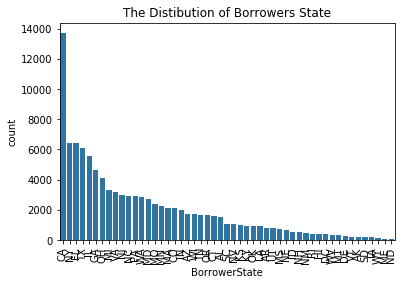

```python
base_color = sb.color_palette()[0]
cat_order = df_clean['BorrowerState'].value_counts().index
sb.countplot(data = df_clean, x = 'BorrowerState', color = base_color, order = cat_order)
plt.xticks(rotation=90)
plt.title('The Distibution of Borrowers State')
```

#### What do the borrowers do?

The top 5 occupations of the borrowers come from are Professional, Compute Programmer, Executive, Teache, and Admistrative Assistant. (The most occupation choice is acctually "Other", but was not included here).

```
Text(0.5,1,'The top 20 Boroower Occupations')
```

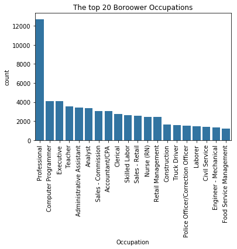

```python
df_temp =  df_clean.drop(df_clean[df_clean['Occupation']=="Other"].index) #Drop rows when occupation is "Other"
cat_order = df_temp['Occupation'].value_counts().index[0:20]
sb.countplot(data = df_temp, x = 'Occupation', color = base_color, order = cat_order)
plt.xticks(rotation=90)
plt.title('The top 20 Boroower Occupations')
```

#### The distribution of stated income for borrowers?

After removing outliers (stated income greater than 25,000), we found most borrowers have a stated monthly income around $5,000.

```
Text(0.5,1,'Monthly Income distribution($0-25,000)')
```

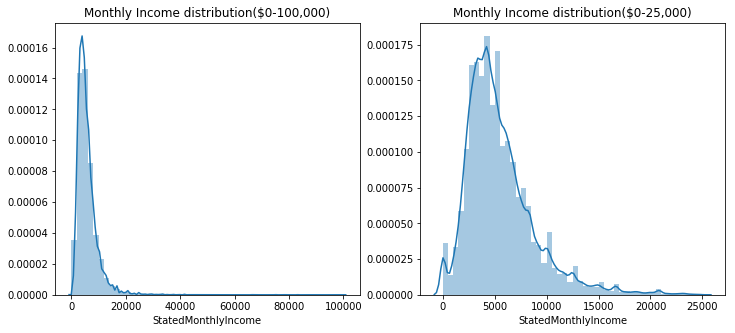

```python
plt.figure(figsize = [12, 5])
plt.subplot(1, 2, 1)
sb.distplot(df_clean['StatedMonthlyIncome'])
plt.title('Monthly Income distribution($0-100,000)')
plt.subplot(1, 2, 2)
sb.distplot(df_clean[df_clean['StatedMonthlyIncome']<25000]['StatedMonthlyIncome'])
plt.title('Monthly Income distribution($0-25,000)')
```

#### How's the stated income distributed for borrowers from different state/occupation?

we looked into the borrowers who gain up to $25,000 per month from the top 10 states/occupation. For these borrowers, the occupation have larger impact on income campared with location/state.

```
Text(0.5,1,'Monthly Income($0-25,000) for Different Occupation')
```

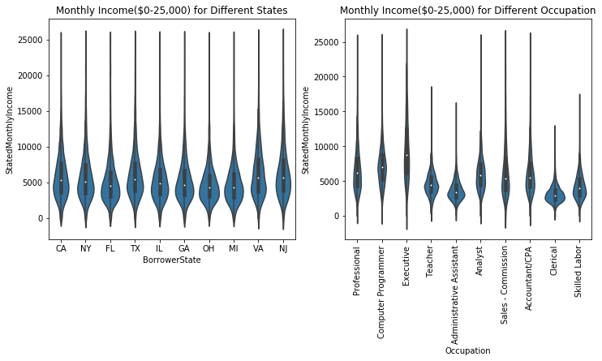

```python
#remove income greater than 25000
df_temp=df_clean.drop(df_clean[df_clean['StatedMonthlyIncome']>25000].index)
cat_order1 = df_clean['BorrowerState'].value_counts().index[0:10]
cat_order2 = df_clean['Occupation'].value_counts().index[1:11]
plt.figure(figsize = [12, 5])
# left plot: state
plt.subplot(1, 2, 1)
ax1 = sb.violinplot(data = df_temp, x = 'BorrowerState', y = 'StatedMonthlyIncome', color = base_color, order = cat_order1)
plt.title('Monthly Income($0-25,000) for Different States')
# right plot: occupation
plt.subplot(1, 2, 2)
ax1 = sb.violinplot(data = df_temp, x = 'Occupation', y = 'StatedMonthlyIncome', color = base_color, order = cat_order2)
plt.xticks(rotation=90)
plt.title('Monthly Income($0-25,000) for Different Occupation')
```

#### Lets look into the income distribution for the top 5 occupations

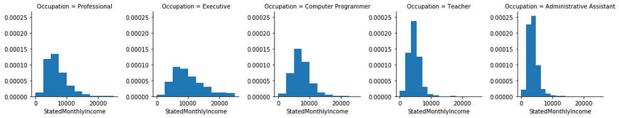

```python
cat_order3 = df_clean['Occupation'].value_counts().index[1:6]
g = sb.FacetGrid(data = df_temp[df_temp['Occupation'].isin(cat_order3)], col = 'Occupation')
g.map(plt.hist, "StatedMonthlyIncome", density = True)
```

#### Check Linear relationship between BorrowerAPR and BorrowerRate

Those two variables should have strong positive linear relationship: the higher Annual Percentage Rate (APR), ther higher interest rate for the loan. Thus we will only use BorrowerRate for further analysis.

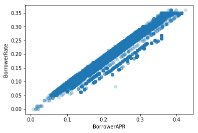

```python
sb.regplot(data = df_clean, x = 'BorrowerAPR', y = 'BorrowerRate', fit_reg = False,
            scatter_kws = {'alpha' : 1/5})
```

We chose a subset sample (n=1000) from the dataframe to avoid overplotting problem. A negative correlation between BorrowerRate and CreditScoreMean was observed. A borrower with better credit history is expected to have lower loan interest.

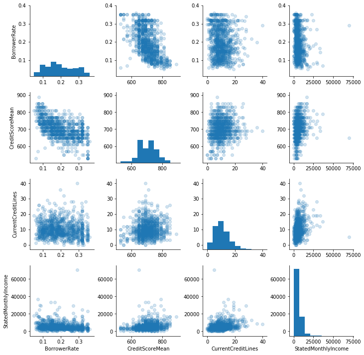

```python
df_sub=df_clean.sample(1000)
g = sb.PairGrid(data = df_sub, vars = ['BorrowerRate', 'CreditScoreMean', 'CurrentCreditLines','StatedMonthlyIncome'])
g.map_diag(plt.hist)
g.map_offdiag(plt.scatter,alpha=.2)
```

#### How's this relationship between BorrowerRate and CreditScoreMean the top 3 occupations?

The negative correlation between BorrowerRate and CreditScoreMean was further confirmed in the borrowers with the top 3 occupations (Professional, Compute Programmer, Executive). The relationship between BorrowerRate and CreditScoreMean was best captured by group of 'Professional' among these three.

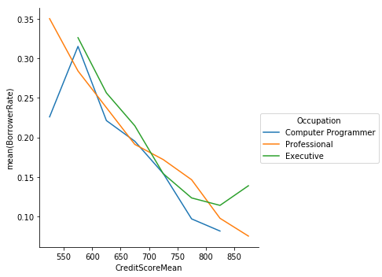

```python
#try line plot
def mean_poly(x, y, bins = 100, **kwargs):
    """ Custom adapted line plot code. """
    # set bin edges if none or int specified
    if type(bins) == int:
        bins = np.linspace(x.min(), x.max(), bins+10)
    bin_centers = (bin_edges[1:] + bin_edges[:-1]) / 2

    # compute counts
    data_bins = pd.cut(x, bins, right = False,
                       include_lowest = True)
    means = y.groupby(data_bins).mean()

    # create plot
    plt.errorbar(x = bin_centers, y = means, **kwargs)

cat_list = df_clean['Occupation'].value_counts().index[1:4]
bin_edges = np.arange(500, df_clean['CreditScoreMean'].max()+50, 50)
g = sb.FacetGrid(data = df_clean[df_clean['Occupation'].isin(cat_list)].sample(500), hue = 'Occupation', size = 5)
g.map(mean_poly, 'CreditScoreMean', 'BorrowerRate', bins = bin_edges)
g.set_ylabels('mean(BorrowerRate)')
g.add_legend()
```

### Overview/Conclusions

**Where do the borrowers come from? What do they do?**

> The top 5 states where the borrowers come from are Califonia, New York, Florida, Texas, Illinois. The top 5 occupations of the borrowers come from are Professional, Compute Programmer, Executive, Teache, and Admistrative Assistant.

**How's the stated income distributed for borrowers from different state/occupation?**

> Most borrowers have a stated monthly income around 5,000 dollars. Occupation tends to have a larger impact on income campared with location/state.

> A negative correlation between BorrowerRate and CreditScoreMean was observed: a borrower with better credit history is expected to have lower loan interest. This trean was further testfied in the borrowers with the top 3 occupations (Professional, Compute Programmer, Executive)

```python
#final check
from subprocess import call
call(['python', '-m', 'nbconvert', 'Analyze_ab_test_results_notebook.ipynb'])
```